# Replication Paper for Statistics II: Statistical Modeling & Causal Inference

Uni Lee

2020-05-15

Cortina and Rottinghaus(2019). Vote centers and turnout by election type in Texas.

# 1. Summary

Cortina and Rottinghaus test the effectiveness of voting centers on increasing vote participation (turnout). In theory, installing a series of centeralized voting centers decreases the cost of voting. People who are interested in voting are more likely to utilize them. Hence, the hypothesis is that presence of voting centers should have a more positive effect on turnout rate for Presidential and Midterm elections whose turnout rates are traditionally higher. Voting centers will have less effect on turnout rate for Constitutional elections.

The researchers could not reject the null hypothesis. The difference-in-difference fixed effects estimand of vote centers on turnout in Presidential and Mid-term elections were -0.001 and 0.015 respectively, and were not statistically significant. In Constitutional elections, the difference-in-difference fixed effects estimand of vote centers was 0.0536. Over time, the effect of vote centers has only a small effect on turnout.

As implied above, the statistical model used in this study is difference-in-difference fixed effects with county-clustered standard errors. The estimand given by this model is the difference between the average turnout for counties with vote centers and counties with no vote centers before and after implementing them. There are two assumptios about the data: *1) vote center is the only factor that affects turnout, and a county’s turnout is not affected by the presence of vote centers in other counties (SUTVA);* and *2) after conditioning on confounders, treatment condition is independent of the potential outcomes (ignorability assumption)*.

# 2. Exploring the Dataset

```r
set.seed(42) #for consistent results

# load libraries
library(tidyverse)
library(haven)
library(dplyr)
library(tidyr)
library(ggplot2)
library(sjPlot)
library(sjmisc)
library(sjlabelled)
library(lmtest)
library(plm)
library(stargazer)
library(MatchIt)
library(lubridate)
```

```r
# load data and change the class of "year" and "votecenter" to "date" and "factor".
raw <- read_dta("Rottinghaus_Cortina_Vote Centers and Turnout by Election Type in Texas_Data.dta") %>%
  mutate(votecenter=factor(votecenter),
         year=year(as.Date(as.character(year), format="%Y")))

# take variables of our interest
a <- raw %>%
  select(county, election, year, votecenter, turnout, medianinc_rec, totalpop_rec, bachelor_higher) %>% arrange(county, election)

# check the number of counties
length(unique(a$county))
```

```
## [1] 254
```

```r
# there is no NA in our dataset
sum(is.na(a))
```

```
## [1] 0
```

The dataset shows vote turnout rates in 254 counties in Texas for 3 different types of elections before and after vote centers were introduced. Variables of our interest in the dataset are:

- `turnout`: the percentage of voters out of the total number of eligible registered voters in a given county (outcome variable)
- `votecenter` : presence of vote center (binary, treatment variable)
- `year`: year of election
- `county`: county name
- `election`: Type of election
- `totalpop_rec`: county population
- `medianinc_rec`: median income
- `bachelor_higher`: share of people who have received higher education

# 3. Difference-in-difference and Fixed Effects Regression Model

$$Y_{it} = β0 + β1*[Time] + β2*[Vote Center] + β3*[Time*Vote Center]$$
$$+ β4*[Median Income] + β5*[Potal Population] + β6*[Bachelor Degree] + q_{it}$$

*where i = county, t = year (1 after implementation, 0 before implementation)*

and

*Diff-in-Diff with Fixed Effects Estimator is β3*

# 4. Replicate Table 1

## 4.1 Prepping data

The author coded the variable `year` into a dummy variable `Time_P`, `Time_M`,`Time_C` that gives value 0 to time before introducing vote centers, and 1 to after they were introduced for each election type. The author also stratified the results into election types to account for unit fixed effects.

```r
# Create 3 new variables that indicate time.
at <- a %>% mutate(time_p =
               case_when(
                 year == 2016 ~ "1",
                 year == 2012 ~ "0"),
             time_m =
               case_when(
                 year == 2018 ~ "1",
                 year == 2010 ~ "0"),
             time_c =
               case_when(
                 year == 2017 ~ "1",
                 year == 2009 ~ "0"))
```

## 4.2 Regression Results

```r
# Presidential
tb1_p <- plm(turnout ~ votecenter*time_p + medianinc_rec + totalpop_rec + bachelor_higher, data=at, index=c("county"), model="within")

# Midterm
tb1_m <- plm(turnout ~ votecenter*time_m + medianinc_rec + totalpop_rec + bachelor_higher, data=at, index=c("county"), model="within")

# Constitutional
tb1_c <- plm(turnout ~ votecenter*time_c + medianinc_rec + totalpop_rec + bachelor_higher, data=at, index=c("county"), model="within")

tab_model(tb1_p, tb1_m, tb1_c,
          show.ci=FALSE, collapse.se=TRUE, p.style="asterisk", show.intercept=TRUE,
          title="Replicated Table 1",
          robust=TRUE,
          dv.labels = c("Presidential", "Midterm", "Constitutional"),
          pred.labels=c("Vote center (1=yes/0=no)", "Time_P (1=2016/0=2012)", "Median income", "Total population", "Bachelor's degree or higher", "Time_P*Vote center", "Time_M (1=2018/0=2010)", "Time_M*Vote center", "Time_C (1=2017/0=2009)", "Time_C*Vote center"),
          string.pred="Variables",
          order.terms = c(1, 2, 6, 7, 8, 9, 10, 3, 5, 4),
          digits=3

)
```

Replicated Table 1

Presidential

Midterm

Constitutional

Variables

Estimates

Estimates

Estimates

Vote center (1=yes/0=no)

0.005  
(0.007)

0.000  
(0.031)

-0.028  
(0.059)

Time_P (1=2016/0=2012)

-0.004  
(0.003)

Time_P*Vote center

-0.001  
(0.006)

Time_M (1=2018/0=2010)

0.104 ***  
(0.005)

Time_M*Vote center

0.015  
(0.031)

Time_C (1=2017/0=2009)

-0.054 ***  
(0.007)

Time_C*Vote center

0.054  
(0.059)

Median income

0.000  
(0.006)

-0.004  
(0.006)

0.009  
(0.006)

Bachelor’s degree or higher

-0.012  
(0.116)

0.228  
(0.146)

-0.134  
(0.095)

Total population

-0.121 **  
(0.042)

0.250  
(0.136)

0.055  
(0.064)

Observations

508

508

508

R<sup>2</sup> / R<sup>2</sup> adjusted

0.026 / -0.991

0.820 / 0.631

0.407 / -0.212

- p<0.05 ** p<0.01 *** p<0.001

## 4.3 Clustered standard errors

```r
# Presidential
coeftest(tb1_p, vcov=vcovHC(tb1_p, cluster="group"))
```

```
##
## t test of coefficients:
##
##                        Estimate  Std. Error t value Pr(>|t|)
## votecenter1          0.00501364  0.00635632  0.7888 0.431003
## time_p1             -0.00376307  0.00340057 -1.1066 0.269539
## medianinc_rec        0.00033554  0.00610514  0.0550 0.956214
## totalpop_rec        -0.12063831  0.03751936 -3.2154 0.001476 **
## bachelor_higher     -0.01169545  0.11270721 -0.1038 0.917437
## votecenter1:time_p1 -0.00064569  0.00605000 -0.1067 0.915093
## ---
## Signif. codes:  0 '***' 0.001 '**' 0.01 '*' 0.05 '.' 0.1 ' ' 1
```

```r
# Midterm
coeftest(tb1_m, vcov=vcovHC(tb1_p, cluster="group"))
```

```
##
## t test of coefficients:
##
##                    Estimate  Std. Error t value  Pr(>|t|)
## votecenter1      4.8664e-05  6.3563e-03  0.0077   0.99390
## medianinc_rec   -4.2610e-03  6.1051e-03 -0.6979   0.48587
## totalpop_rec     2.4976e-01  3.7519e-02  6.6568 1.785e-10 ***
## bachelor_higher  2.2832e-01  1.1271e-01  2.0258   0.04386 *
## ---
## Signif. codes:  0 '***' 0.001 '**' 0.01 '*' 0.05 '.' 0.1 ' ' 1
```

```r
# Constitutional
coeftest(tb1_c, vcov=vcovHC(tb1_p, cluster="group"))
```

```
##
## t test of coefficients:
##
##                   Estimate Std. Error t value  Pr(>|t|)
## votecenter1     -0.0284803  0.0063563 -4.4806 1.137e-05 ***
## medianinc_rec    0.0086165  0.0061051  1.4114    0.1594
## totalpop_rec     0.0554176  0.0375194  1.4770    0.1409
## bachelor_higher -0.1341180  0.1127072 -1.1900    0.2352
## ---
## Signif. codes:  0 '***' 0.001 '**' 0.01 '*' 0.05 '.' 0.1 ' ' 1
```

# 5. Replicate Table 2

## 5.1 Prepping Data

```r
# Subset Constitutional election data
b <- a %>% filter(election=="Constitutional") %>%
# Create dummy variables
  mutate(time_c1 = case_when(
                 year == 2011 ~ "1",
                 year == 2009 ~ "0"),
         time_c2 = case_when(
                 year == 2017 ~ "1",
                 year == 2011 ~ "0"),
         time_c3 = case_when(
                 year == 2017 ~ "1",
                 year == 2015 ~ "0"))
```

## 5.2 Regression models and results

```r
tb2_c1 <- plm(turnout ~ votecenter*time_c1 + medianinc_rec + totalpop_rec + bachelor_higher, data=b, index=c("county"), model="within")

tb2_c2 <- plm(turnout ~ votecenter*time_c2 + medianinc_rec + totalpop_rec + bachelor_higher, data=b, index=c("county"), model="within")

tb2_c3 <- plm(turnout ~ votecenter*time_c3 + medianinc_rec + totalpop_rec + bachelor_higher, data=b, index=c("county"), model="within")

stargazer(tb2_c1, tb2_c2, tb2_c3,
          title="Replicated Table 2: Constitutional",
          align=TRUE,
          column.labels = c("2009-2011", "2011-2017", "2015-2017"),
          order=c(1, 2, 8, 3, 9, 4, 10, 5, 7, 6),
          digits=5,
          type="html")
```

**Replicated Table 2: Constitutional**

|  | *Dependent variable:* |  |  |
| --- | --- | --- | --- |
|  | turnout |  |  |
|  | 2009-2011 | 2011-2017 | 2015-2017 |
|  | (1) | (2) | (3) |
| votecenter1 | 0.02534 | -0.02588 | 0.01057 |
|  | (0.02866) | (0.02150) | (0.01748) |
| time_c11 | -0.03567*** |  |  |
|  | (0.00342) |  |  |
| votecenter1:time_c11 | -0.00929 |  |  |
|  | (0.02046) |  |  |
| time_c21 |  | -0.01042* |  |
|  |  | (0.00553) |  |
| votecenter1:time_c21 |  | 0.04398** |  |
|  |  | (0.02029) |  |
| time_c31 |  |  | -0.05636*** |
|  |  |  | (0.00550) |
| votecenter1:time_c31 |  |  | 0.01036 |
|  |  |  | (0.01025) |
| medianinc_rec | -0.00672 | 0.00322 | 0.00120 |
|  | (0.00770) | (0.00553) | (0.00723) |
| bachelor_higher | -0.10328 | 0.01434 | 0.04399 |
|  | (0.09376) | (0.11516) | (0.20320) |
| totalpop_rec | 0.12684 | -0.00395 | -0.24167 |
|  | (0.15589) | (0.09133) | (0.31142) |
| Observations | 508 | 508 | 508 |
| R<sup>2</sup> | 0.47462 | 0.03822 | 0.47835 |
| Adjusted R<sup>2</sup> | -0.07407 | -0.96622 | -0.06643 |
| F Statistic (df = 6; 248) | 37.33956*** | 1.64254 | 37.90292*** |
| *Note:* | p<0.1; p<0.05; p<0.01 |  |  |

## 5.3 Clustered standard errors

```r
# Constitutional 1
coeftest(tb1_p, vcov=vcovHC(tb2_c1, cluster="group"))
```

```
##
## t test of coefficients:
##
##                    Estimate  Std. Error t value Pr(>|t|)
## votecenter1      0.00501364  0.01530386  0.3276   0.7435
## medianinc_rec    0.00033554  0.00761909  0.0440   0.9649
## totalpop_rec    -0.12063831  0.09699049 -1.2438   0.2147
## bachelor_higher -0.01169545  0.12075016 -0.0969   0.9229
```

```r
# Constitutional 2
coeftest(tb1_m, vcov=vcovHC(tb2_c2, cluster="group"))
```

```
##
## t test of coefficients:
##
##                    Estimate  Std. Error t value  Pr(>|t|)
## votecenter1      4.8664e-05  2.6861e-02  0.0018   0.99856
## medianinc_rec   -4.2610e-03  5.1018e-03 -0.8352   0.40442
## totalpop_rec     2.4976e-01  4.3833e-02  5.6979 3.427e-08 ***
## bachelor_higher  2.2832e-01  1.1971e-01  1.9073   0.05763 .
## ---
## Signif. codes:  0 '***' 0.001 '**' 0.01 '*' 0.05 '.' 0.1 ' ' 1
```

```r
# Constitutional 3
coeftest(tb1_c, vcov=vcovHC(tb2_c3, cluster="group"))
```

```
##
## t test of coefficients:
##
##                   Estimate Std. Error t value Pr(>|t|)
## votecenter1     -0.0284803  0.0159316 -1.7877  0.07505 .
## medianinc_rec    0.0086165  0.0073166  1.1777  0.24006
## totalpop_rec     0.0554176  0.2272343  0.2439  0.80753
## bachelor_higher -0.1341180  0.1663520 -0.8062  0.42088
## ---
## Signif. codes:  0 '***' 0.001 '**' 0.01 '*' 0.05 '.' 0.1 ' ' 1
```

# 6. Replicate Table 3

## 6.1 Prepping Data

```r
# Presidential
p <- a %>% filter(election=="Presidential") %>%
  mutate(time_p=(ifelse(year==2016, 0, 1)))

# Mid-term/gubernatorial
m <- a %>% filter(election=="Midterm/Gubernatorial" & year==2010 | year==2018) %>%
  mutate(time_m=(ifelse(year==2018, 1, 0)))

# Constitutional
c <- a %>% filter(election=="Constitutional" & year==2017 | year==2009) %>%
  mutate(time_c=(ifelse(year==2017, 1, 0)))
```

## 6.2 Matching

```r
# matching on 3 covariates
p_match <- matchit(votecenter ~ medianinc_rec + totalpop_rec + bachelor_higher,
                   method = "nearest",
                   ratio = 1,
                   replace = TRUE,
                   data = p)

m_match <- matchit(votecenter ~ medianinc_rec + totalpop_rec + bachelor_higher,
                   method = "nearest",
                   ratio = 1,
                   replace = TRUE,
                   data = m)

c_match <- matchit(votecenter ~ medianinc_rec + totalpop_rec + bachelor_higher,
                   method = "nearest",
                   ratio = 1,
                   replace = TRUE,
                   data = c)

# Grab data
p_match_data <- match.data(p_match)
m_match_data <- match.data(m_match)
c_match_data <- match.data(c_match)
```

## 6.3 Regression Results

```r
# linear regression using matched data
tb3_p <- lm(turnout ~ votecenter*time_p + medianinc_rec + totalpop_rec + bachelor_higher, data=p_match_data)
tb3_m <- lm(turnout ~ votecenter*time_m + medianinc_rec + totalpop_rec + bachelor_higher, data=m_match_data)
tb3_c <- lm(turnout ~ votecenter*time_c + medianinc_rec + totalpop_rec + bachelor_higher, data=c_match_data)

tab_model(tb3_p, tb3_m, tb3_c,
          show.ci=FALSE, collapse.se=TRUE, p.style="asterisk", show.intercept=TRUE,
          title="Replicated Table 3",
          robust=TRUE,
          dv.labels = c("Presidential", "Midterm", "Constitutional"),
          pred.labels=c("Constant", "Vote center (1=yes/0=no)", "Time_P (1=2016/0=2012)", "Median income", "Total population", "Bachelor's degree or higher", "Time_P*Vote center", "Time_M (1=2018/0=2010)", "Time_M*Vote center", "Time_C (1=2017/0=2009)", "Time_C*Vote center"),
          string.pred="Variables",
          order.terms = c(2, 3, 7, 8, 9, 10, 11, 4, 6, 5, 1),
          digits=5)
```

Replicated Table 3

Presidential

Midterm

Constitutional

Variables

Estimates

Estimates

Estimates

Vote center (1=yes/0=no)

-0.01294  
(0.01032)

-0.03374  
(0.05100)

-0.02651  
(0.02292)

0.00820  
(0.01285)

Time_P*Vote center

-0.00879  
(0.01984)

Time_M (1=2018/0=2010)

0.06218 *  
(0.02693)

Time_M*Vote center

0.05791  
(0.05258)

Time_C (1=2017/0=2009)

-0.05256 **  
(0.01616)

Time_C*Vote center

0.03282  
(0.02650)

Median income

0.00383  
(0.00440)

0.00387  
(0.00633)

-0.00150  
(0.00637)

Bachelor’s degree or higher

0.60266 ***  
(0.08239)

0.47891 ***  
(0.09058)

0.09345  
(0.11194)

Total population

-0.15297 ***  
(0.02679)

-0.11336 **  
(0.04102)

-0.03283  
(0.03131)

Constant

0.49325 ***  
(0.01888)

0.32552 ***  
(0.03052)

0.11120 ***  
(0.02119)

Observations

105

107

107

R<sup>2</sup> / R<sup>2</sup> adjusted

0.520 / 0.491

0.413 / 0.378

0.203 / 0.155

- p<0.05 ** p<0.01 *** p<0.001

# 7. Parallel Trend Assumption

In order to hold the parallel trend assumption, the difference between the the counties that have introduced vote centers(treatment group) and those that did not(control group) should be constant without treatment.

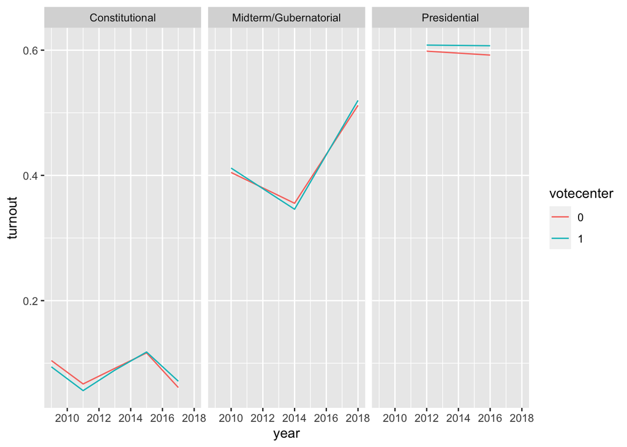

```r
parallel_data <- raw %>% group_by(year, votecenter, election) %>%
  summarise(turnout = mean(turnout))

ggplot(data=parallel_data, aes(x=year, y=turnout, color=votecenter)) +
  geom_line() + facet_grid(~election)
```

# 8. Robustness Test

## 8.1 SUTVA: No interference

For the result to be robust, another assumption must hold: SUTVA (Stable Unit Treatment Value Assumption). That is the potential outcome of one subject is not affected by other subjects’ assignment to the treatment. In their [supplementary material](https://journals.sagepub.com/doi/suppl/10.1177/2053168019864224/suppl_file/Vote_Center_Supplemental_Materials_RR3.pdf), the authors argue that there is “no reason to believe that the assumption does not hold” without providing statistical test.

The authors make this assumption because in theory, whether a county has vote centers should not affect the turnout in another county. However, this may not be necessarily true because increased social media use over the years may have led to correlation between the treatment assignment and potential outcome.

Social media (i.e. Instagram, Whatsapp, Facebook, / etc.) use increases the likelihood that people hear about other counties’ experience of going to vote centers via Instagram or Whatsapp. Exposure to such news increases interest in vote centers, which may increase turnout as a result.

This alternative view cannot be statistically tested due to lack of data on social media use over time.

## 8.2 Placebo test using previous periods

For an additional diagnostics, we can exclude post-treatment data and assign pre-treatment data as “placebo” treatment period. Then, we re-estimate the diff-in-diff estimand. The placebo test should give neither statistically nor substantially significant estimands because the placebo time variable is actually pre-treatment!

```r
# filter post-treatment data from the dataset.
# NOTE: Cannot do this placebo test on presidential because there is no data prior to 2012.

placebo <- raw %>% filter(year %in% c(2012, 2011, 2009, 2010, 2013, 2015, 2014)) %>%
        mutate(time_m =
               case_when(
                 year == 2014 ~ "1",
                 year == 2010 ~ "0"),
             time_c =
               case_when(
                 year == 2015 ~ "1",
                 year == 2009 ~ "0"))

# Midterm
placebo_m <- plm(turnout ~ votecenter*time_m + medianinc_rec + totalpop_rec + bachelor_higher, data=placebo, index=c("county"), model="within")

# Constitutional
placebo_c <- plm(turnout ~ votecenter*time_c + medianinc_rec + totalpop_rec + bachelor_higher, data=placebo, index=c("county"), model="within")

stargazer(placebo_m, placebo_c, type="html")
```

|  | *Dependent variable:* |  |
| --- | --- | --- |
|  | turnout |  |
|  | (1) | (2) |
| votecenter1 | 0.034 | 0.006 |
|  | (0.027) | (0.023) |
| time_m1 | -0.056*** |  |
|  | (0.004) |  |
| time_c1 |  | 0.012*** |
|  |  | (0.004) |
| medianinc_rec | 0.012 | -0.007 |
|  | (0.008) | (0.006) |
| totalpop_rec | 0.047 | 0.102 |
|  | (0.134) | (0.063) |
| bachelor_higher | 0.158 | 0.095 |
|  | (0.124) | (0.075) |
| votecenter1:time_m1 | -0.016 |  |
|  | (0.024) |  |
| votecenter1:time_c1 |  | 0.006 |
|  |  | (0.022) |
| Observations | 508 | 508 |
| R<sup>2</sup> | 0.486 | 0.108 |
| Adjusted R<sup>2</sup> | -0.051 | -0.823 |
| F Statistic (df = 6; 248) | 39.028*** | 5.006*** |
| *Note:* | p<0.1; p<0.05; p<0.01 |  |

The regression results have produced estimands that are close to 0 and not statistically significant. Therefore, the original diff-in-diff estimands with fixed effects appear robust.